# Loan Data Prosper Exploration

###### Muhammad Ariq Farhansyah Mutyara

## Preliminary Wrangling

This data set contains 113,937 loans with 81 variables on each loan, including loan amount, borrower rate (or interest rate), current loan status, borrower income, and many others.

```python
#Import all essential packages
import numpy as np
import pandas as pd
import seaborn as sns
import matplotlib.pyplot as plt

%matplotlib inline
```

```python
loan_data = pd.read_csv('prosperLoanData.csv')
loan_data.head()
```

|  | ListingKey | ListingNumber | ListingCreationDate | CreditGrade | Term | LoanStatus | ClosedDate | BorrowerAPR | BorrowerRate | LenderYield | ... | LP_ServiceFees | LP_CollectionFees | LP_GrossPrincipalLoss | LP_NetPrincipalLoss | LP_NonPrincipalRecoverypayments | PercentFunded | Recommendations | InvestmentFromFriendsCount | InvestmentFromFriendsAmount | Investors |
| --- | --- | --- | --- | --- | --- | --- | --- | --- | --- | --- | --- | --- | --- | --- | --- | --- | --- | --- | --- | --- | --- |
| 0 | 1021339766868145413AB3B | 193129 | 2007-08-26 19:09:29.263000000 | C | 36 | Completed | 2009-08-14 00:00:00 | 0.16516 | 0.1580 | 0.1380 | ... | -133.18 | 0.0 | 0.0 | 0.0 | 0.0 | 1.0 | 0 | 0 | 0.0 | 258 |
| 1 | 10273602499503308B223C1 | 1209647 | 2014-02-27 08:28:07.900000000 | NaN | 36 | Current | NaN | 0.12016 | 0.0920 | 0.0820 | ... | 0.00 | 0.0 | 0.0 | 0.0 | 0.0 | 1.0 | 0 | 0 | 0.0 | 1 |
| 2 | 0EE9337825851032864889A | 81716 | 2007-01-05 15:00:47.090000000 | HR | 36 | Completed | 2009-12-17 00:00:00 | 0.28269 | 0.2750 | 0.2400 | ... | -24.20 | 0.0 | 0.0 | 0.0 | 0.0 | 1.0 | 0 | 0 | 0.0 | 41 |
| 3 | 0EF5356002482715299901A | 658116 | 2012-10-22 11:02:35.010000000 | NaN | 36 | Current | NaN | 0.12528 | 0.0974 | 0.0874 | ... | -108.01 | 0.0 | 0.0 | 0.0 | 0.0 | 1.0 | 0 | 0 | 0.0 | 158 |
| 4 | 0F023589499656230C5E3E2 | 909464 | 2013-09-14 18:38:39.097000000 | NaN | 36 | Current | NaN | 0.24614 | 0.2085 | 0.1985 | ... | -60.27 | 0.0 | 0.0 | 0.0 | 0.0 | 1.0 | 0 | 0 | 0.0 | 20 |

5 rows × 81 columns

```python
loan_data.info()
```

```
<class 'pandas.core.frame.DataFrame'>
RangeIndex: 113937 entries, 0 to 113936
Data columns (total 81 columns):
 #   Column                               Non-Null Count   Dtype
---  ------                               --------------   -----
 0   ListingKey                           113937 non-null  object
 1   ListingNumber                        113937 non-null  int64
 2   ListingCreationDate                  113937 non-null  object
 3   CreditGrade                          28953 non-null   object
 4   Term                                 113937 non-null  int64
 5   LoanStatus                           113937 non-null  object
 6   ClosedDate                           55089 non-null   object
 7   BorrowerAPR                          113912 non-null  float64
 8   BorrowerRate                         113937 non-null  float64
 9   LenderYield                          113937 non-null  float64
```

[output cut: 73 more lines]

```python
#Choose the column we want to analyze
coll = ['ListingNumber', 'Term', 'LoanStatus',
        'BorrowerAPR', 'ProsperRating (Alpha)', 'ProsperScore',
        'BorrowerState', 'Occupation', 'DebtToIncomeRatio',
        'IncomeRange', 'LoanOriginalAmount', 'MonthlyLoanPayment',
        'Investors']
```

```python
df = loan_data[coll]
```

```python
#Check if there is a null value
df.isnull().sum()
```

```
ListingNumber                0
Term                         0
LoanStatus                   0
BorrowerAPR                 25
ProsperRating (Alpha)    29084
ProsperScore             29084
BorrowerState             5515
Occupation                3588
DebtToIncomeRatio         8554
IncomeRange                  0
LoanOriginalAmount           0
MonthlyLoanPayment           0
Investors                    0
dtype: int64
```

```python
#Drop the null value
df = df.dropna(subset=['ProsperScore', 'DebtToIncomeRatio', 'Occupation']).reset_index(drop=True)
```

```python
#Change the collumn name
df = df.rename({'ProsperRating (Alpha)' : 'ProsperRating',
                'ListingCategory (numeric)' : 'ListingCategory'}, axis=1)
```

```python
#Check the categorical column
print(df['Term'].value_counts())
print(df['LoanStatus'].value_counts())
print(df['ProsperRating'].value_counts())
print(df['ProsperScore'].value_counts())
df['IncomeRange'].value_counts()
```

```
36    51926
60    22884
12     1414
Name: Term, dtype: int64
Current                   51174
Completed                 17690
Chargedoff                 4445
Defaulted                   885
Past Due (1-15 days)        714
Past Due (31-60 days)       322
Past Due (91-120 days)      277
Past Due (61-90 days)       275
Past Due (16-30 days)       241
FinalPaymentInProgress      187
Past Due (>120 days)         14
Name: LoanStatus, dtype: int64
C     16501
B     14379
A     13491
D     12631
E      8443
HR     5682
AA     5097
Name: ProsperRating, dtype: int64
8.0     11432
6.0     11157
4.0     10826
7.0      9817
5.0      8646
9.0      6589
3.0      6374
2.0      4675
10.0     4601
11.0     1392
1.0       715
Name: ProsperScore, dtype: int64
```

```
$50,000-74,999    23696
$25,000-49,999    21422
$100,000+         13980
$75,000-99,999    13547
$1-24,999          3578
Not employed          1
Name: IncomeRange, dtype: int64
```

```python
#Delete row where Income range is Not Employed
df = df[df['IncomeRange'] != 'Not employed'].reset_index(drop=True)
```

```python
#Change the data type to categorical variabel

#Term Column
term = [12, 36, 60]
term_order = pd.api.types.CategoricalDtype(ordered=True, categories=term)
df['Term'] = df['Term'].astype(term_order)

#LoanStatus Column
df['LoanStatus'] = df['LoanStatus'].astype('category')

#ProsperRating Column
rating = ['HR', 'E', 'D', 'C', 'B', 'A', 'AA']
rating_order = pd.api.types.CategoricalDtype(ordered=True, categories=rating)
df['ProsperRating'] = df['ProsperRating'].astype(rating_order)

#ProsperScore Column
score = [i for i in range(1,12)]
score_order = pd.api.types.CategoricalDtype(ordered=True, categories=score)
df['ProsperScore'] = df['ProsperScore'].astype(score_order)

#BorrowerState Column
df['BorrowerState'] = df['BorrowerState'].astype('category')

#Occupation Column
df['Occupation'] = df['Occupation'].astype('category')

#IncomeRange Column
income = ['$1-24,999', '$25,000-49,999', '$50,000-74,999', '$75,000-99,999', '$100,000+']
income_order = pd.api.types.CategoricalDtype(ordered=True, categories=income)
df['IncomeRange'] = df['IncomeRange'].astype(income_order)
```

```python
df.info()
```

```
<class 'pandas.core.frame.DataFrame'>
RangeIndex: 76223 entries, 0 to 76222
Data columns (total 13 columns):
 #   Column              Non-Null Count  Dtype
---  ------              --------------  -----
 0   ListingNumber       76223 non-null  int64
 1   Term                76223 non-null  category
 2   LoanStatus          76223 non-null  category
 3   BorrowerAPR         76223 non-null  float64
 4   ProsperRating       76223 non-null  category
 5   ProsperScore        76223 non-null  category
 6   BorrowerState       76223 non-null  category
 7   Occupation          76223 non-null  category
 8   DebtToIncomeRatio   76223 non-null  float64
 9   IncomeRange         76223 non-null  category
 10  LoanOriginalAmount  76223 non-null  int64
 11  MonthlyLoanPayment  76223 non-null  float64
 12  Investors           76223 non-null  int64
dtypes: category(7), float64(3), int64(3)
memory usage: 4.0 MB
```

```python
df.head()
```

|  | ListingNumber | Term | LoanStatus | BorrowerAPR | ProsperRating | ProsperScore | BorrowerState | Occupation | DebtToIncomeRatio | IncomeRange | LoanOriginalAmount | MonthlyLoanPayment | Investors |
| --- | --- | --- | --- | --- | --- | --- | --- | --- | --- | --- | --- | --- | --- |
| 0 | 1209647 | 36 | Current | 0.12016 | A | 7 | CO | Professional | 0.18 | $50,000-74,999 | 10000 | 318.93 | 1 |
| 1 | 658116 | 36 | Current | 0.12528 | A | 9 | GA | Skilled Labor | 0.15 | $25,000-49,999 | 10000 | 321.45 | 158 |
| 2 | 909464 | 36 | Current | 0.24614 | D | 4 | MN | Executive | 0.26 | $100,000+ | 15000 | 563.97 | 20 |
| 3 | 1074836 | 60 | Current | 0.15425 | B | 10 | NM | Professional | 0.36 | $100,000+ | 15000 | 342.37 | 1 |
| 4 | 750899 | 36 | Current | 0.31032 | E | 2 | KS | Sales - Retail | 0.27 | $25,000-49,999 | 3000 | 122.67 | 1 |

```python
df.describe()
```

|  | ListingNumber | BorrowerAPR | DebtToIncomeRatio | LoanOriginalAmount | MonthlyLoanPayment | Investors |
| --- | --- | --- | --- | --- | --- | --- |
| count | 7.622300e+04 | 76223.000000 | 76223.000000 | 76223.000000 | 76223.000000 | 76223.000000 |
| mean | 7.737307e+05 | 0.223903 | 0.258040 | 9294.919840 | 296.420533 | 70.002020 |
| std | 2.344161e+05 | 0.079374 | 0.320579 | 6413.550574 | 189.676887 | 97.801075 |
| min | 4.162750e+05 | 0.045830 | 0.000000 | 1000.000000 | 0.000000 | 1.000000 |
| 25% | 5.603560e+05 | 0.161570 | 0.150000 | 4000.000000 | 159.040000 | 1.000000 |
| 50% | 7.425050e+05 | 0.215660 | 0.220000 | 8000.000000 | 257.720000 | 32.000000 |
| 75% | 9.747035e+05 | 0.287800 | 0.320000 | 14606.500000 | 392.420000 | 100.000000 |
| max | 1.255149e+06 | 0.423950 | 10.010000 | 35000.000000 | 2251.510000 | 1189.000000 |

### What is the structure of your dataset?

There are 76,223 rows in the dataset with 13 features with 6 columns are numeric, there are **ListingNumber**, **BorrowerAPR**, **DebtToIncomeRatio**, **LoanOriginalAmount**, **MonthlyLoanPayment**, **Investors** and the rests are categorical. With **LoanStatus**, **BorrowerState**, **Occupation** are nominal, and **Term**, **ProsperRating**, **ProsperScore**, and **IncomeRange** are ordinal with the order value from worst to best below.

- **Term** : 12, 36, 60
- **ProsperRating** : HR, E, D, C, B, A, AA
- **ProsperScore** : 1, 2, 3, 4, 5, 6, 7, 8, 9, 10, 11
- **IncomeRange** : \$1-24,999, \\$25,000-49,999, \$50,000-74,999, \\$75,000-99,999, \$100,000+

### What is/are the main feature(s) of interest in your dataset?

What affects the borrower’s APR?

### What features in the dataset do you think will help support your investigation into your feature(s) of interest?

We think that for the most part what affects the borrower's APR is that the Prosper Rating and Prosper Score. We also want to look at Loan Status, Income Range, and Occupation to see whether it is affected borrower's APR or not.

## Univariate Exploration

Now let us take a look at the distribution our interest feature

```python
df['BorrowerAPR'].describe()
```

```
count    76223.000000
mean         0.223903
std          0.079374
min          0.045830
25%          0.161570
50%          0.215660
75%          0.287800
max          0.423950
Name: BorrowerAPR, dtype: float64
```

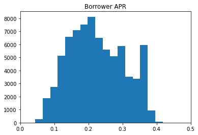

```python
bin_edges = np.arange(0, df['BorrowerAPR'].max()+0.022, 0.022)
plt.hist(df['BorrowerAPR'], bins=bin_edges)
plt.title('Borrower APR')
plt.xlim(0, 0.5);
```

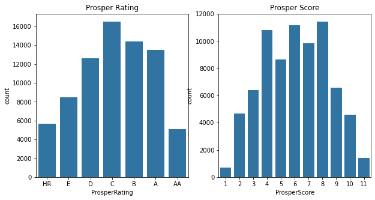

```python
plt.figure(figsize=[10, 5])
base_color = sns.color_palette()[0]

plt.subplot(1, 2, 1)
sns.countplot(data=df, x='ProsperRating', color=base_color)
plt.title('Prosper Rating')

plt.subplot(1, 2, 2)
sns.countplot(data=df, x='ProsperScore', color=base_color)
plt.title('Prosper Score');
```

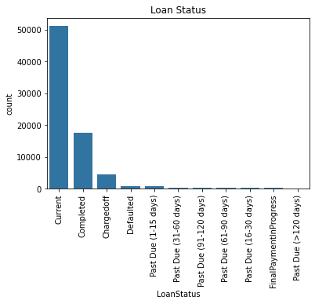

```python
status_order = df['LoanStatus'].value_counts().index
sns.countplot(data=df, x='LoanStatus', color=base_color, order=status_order)
plt.xticks(rotation=90)
plt.title('Loan Status');
```

```python
loan_status = df['LoanStatus'].value_counts().index.tolist()
loan_status
```

```
['Current',
 'Completed',
 'Chargedoff',
 'Defaulted',
 'Past Due (1-15 days)',
 'Past Due (31-60 days)',
 'Past Due (91-120 days)',
 'Past Due (61-90 days)',
 'Past Due (16-30 days)',
 'FinalPaymentInProgress',
 'Past Due (>120 days)']
```

Let us do some Feature Engineering Here for this category, we will put Past Due and Final Payment In Progress Category into Current Category. And combine Chargedoff with Defaulted Category.

```python
status = []
def get_status(dataframe):
    if dataframe['LoanStatus'] in loan_status[:2]:
        status.append(dataframe['LoanStatus'])
    elif dataframe['LoanStatus'] in loan_status[2:4]:
        status.append('Defaulted')
    elif dataframe['LoanStatus'] in loan_status[4:]:
        status.append('Current')
    else:
        status.append('None')

df.apply(get_status, axis=1)
df['LoanStatus'] = status
df['LoanStatus'] = df['LoanStatus'].astype('category')
```

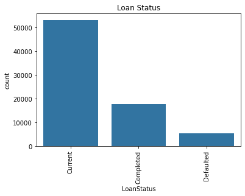

```python
status_order = df['LoanStatus'].value_counts().index
sns.countplot(data=df, x='LoanStatus', color=base_color, order=status_order)
plt.xticks(rotation=90)
plt.title('Loan Status');
```

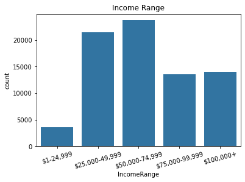

```python
sns.countplot(data=df, x='IncomeRange', color=base_color)
plt.xticks(rotation=15)
plt.title('Income Range');
```

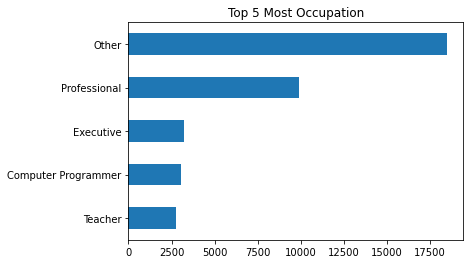

```python
df['Occupation'].value_counts()[4::-1].plot.barh()
plt.title('Top 5 Most Occupation');
```

### Discuss the distribution(s) of your variable(s) of interest. Were there any unusual points? Did you need to perform any transformations?

The BorrowerAPR variable looks like a normal distribution and with the mean and median value almost slightly the same. But there is some high peak in the range of 30% to 35%. For the categorical variable that the vast majority is in C ProsperRating and 8 ProsperScore. For Loan Status, the current status is the loan in the data set with over 50 thousand, following completed and chargedoff status. For income range and occupation, the most borrower is the one with income range between \$50,000-74,999 and for occupation, the other category is the most counted with over 17500 in the Dataset.

### Of the features you investigated, were there any unusual distributions? Did you perform any operations on the data to tidy, adjust, or change the form of the data? If so, why did you do this?

We did some change in the dataset such as doing some feature engineering in Loan Status to make the category looks more clearer.

## Bivariate Exploration

To start off with, We want to look at the pairwise correlations present between features in the data.

```python
num_var = ['BorrowerAPR', 'DebtToIncomeRatio',
           'LoanOriginalAmount', 'MonthlyLoanPayment', 'Investors']
```

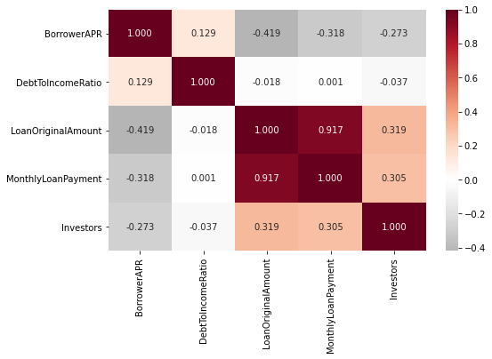

```python
plt.figure(figsize = [8, 5])
sns.heatmap(df[num_var].corr(), annot = True, fmt = '.3f',
           cmap = 'RdGy_r', center = 0)
plt.show()
```

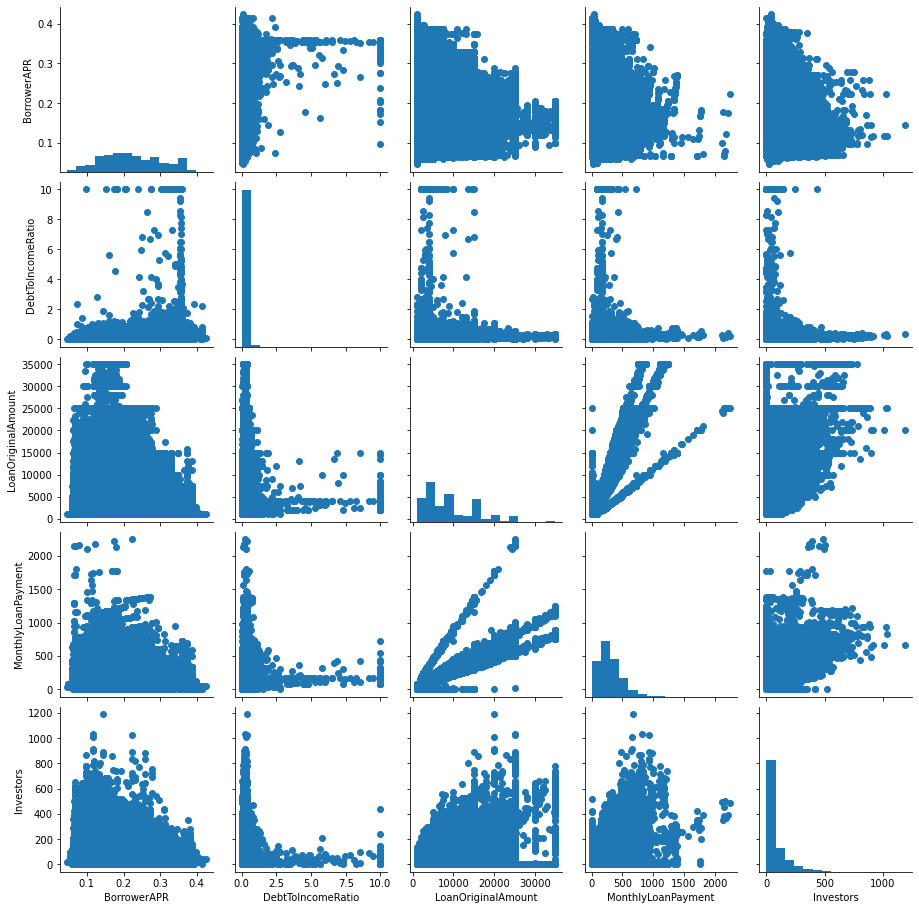

```python
g = sns.PairGrid(data=df, vars=num_var)
g = g.map_diag(plt.hist, bins=15)
g.map_offdiag(plt.scatter);
```

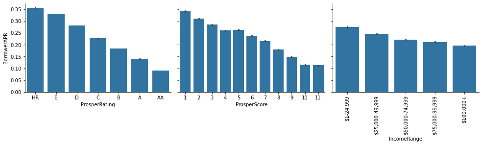

```python
def bargrid(x, y, **kwargs):
    default_color = sns.color_palette()[0]
    sns.barplot(x, y, color=default_color)

plt.figure(figsize=[10, 10])
g = sns.PairGrid(data=df, y_vars=['BorrowerAPR'], x_vars=['ProsperRating', 'ProsperScore', 'IncomeRange'],
                height=3, aspect=1.5)
g.map(bargrid)
plt.xticks(rotation=90)
plt.show();
```

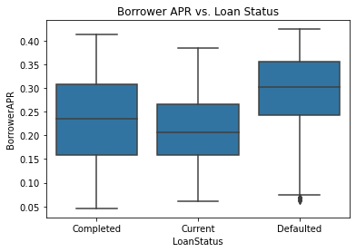

```python
sns.boxplot(data=df, x='LoanStatus', y='BorrowerAPR', color=base_color)
plt.title('Borrower APR vs. Loan Status');
```

```python
index = df[df['LoanStatus'] != 'Current'].index
df_without_current = df.loc[index]
df_without_current['LoanStatus'] = df_without_current['LoanStatus'].cat.remove_unused_categories()
```

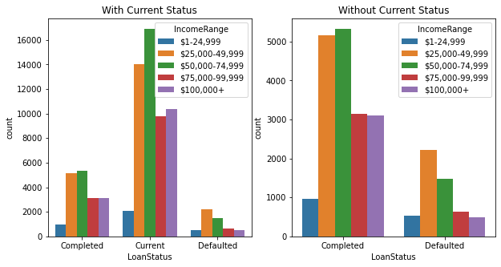

```python
plt.figure(figsize=[10, 5])

plt.subplot(1, 2, 1)
sns.countplot(data=df, x='LoanStatus', hue='IncomeRange')
plt.title('With Current Status')

plt.subplot(1, 2, 2)
sns.countplot(data=df_without_current, x='LoanStatus', hue='IncomeRange')
plt.title('Without Current Status');
```

```python
#Make it just the most 10 occupation categories
occupation = df['Occupation'].value_counts()[1:6].index
occupation = df[df['Occupation'].isin(occupation)].index
top_occupation = df.loc[occupation]
top_occupation['Occupation'] = top_occupation['Occupation'].cat.remove_unused_categories()
```

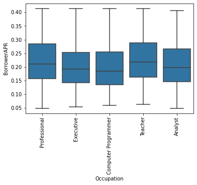

```python
order_most = top_occupation['Occupation'].value_counts().index
sns.boxplot(data=top_occupation, x='Occupation', y='BorrowerAPR', color=base_color, order=order_most)
plt.xticks(rotation=90);
```

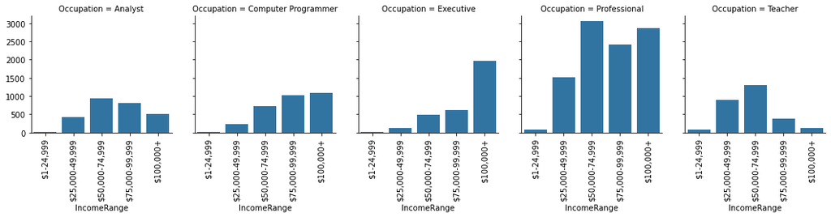

```python
g = sns.FacetGrid(data=top_occupation, col='Occupation')
g.map(sns.countplot, 'IncomeRange')
g.set_xticklabels(rotation=90);
```

### Talk about some of the relationships you observed in this part of the investigation. How did the feature(s) of interest vary with other features in the dataset?

With categorical variabel such as ProsperRating, ProsperScore, and IncomeRange has a high correlation with BorrowerAPR and the higher the order category is, the lower the borrower apr would be. However, we still don't see any pattern and relationship between BorrowerAPR againts Occupation.

## Multivariate Exploration

I this part, we want to see between LoanStatus and IncomeRange and how does it impact on BorrowerAPR

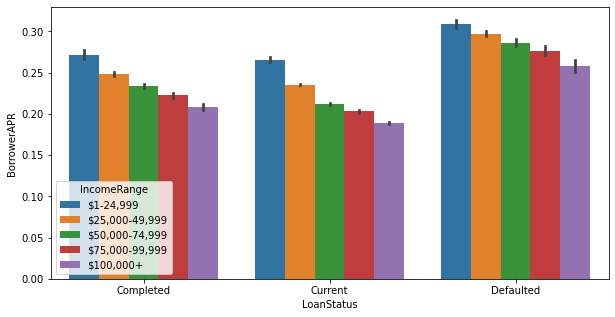

```python
plt.figure(figsize = [10, 5])
sns.barplot(data=df, x='LoanStatus', y='BorrowerAPR', hue='IncomeRange');
```

### Talk about some of the relationships you observed in this part of the investigation. Were there features that strengthened each other in terms of looking at your feature(s) of interest?

We extended the investigation of BorrowerAPR with LoanStatus and IncomeRange with barplot. And we see that there is an obvious pattern and relationship here.

```python
#Save cleaned data
df.to_csv('prosperLoanDataClean.csv', index=False)
```